# Non-Destructive Freshness Assessment in Fish Fillets via NIR Spectroscopy: Multivariate Optimization and K-value Classification Strategies

Luca Bernardi

2026-06-24

## **Introduction**

### Study Objectives

This report is the coherent evolution of the first project on Near-Infrared (NIR) spectroscopy. The previous analysis suffered from high dimensionality: with a small sample size and 140 spectral wavelengths, the data were sparse, an unfavourable setting for any classification algorithm.Building on those investigations, the present study pursues a single objective: to reduce the dimensionality of the NIR spectra through a chemically interpretable strategy, and to assess whether the previous results hold or whether classification improves.

As a brief recall, the K-value reflects the progressive degradation of adenosine triphosphate (ATP) driven by post-mortem muscle biochemistry, and is a recognised standard for freshness assessment in fish.

$$K(\%) = \frac{[Inosine] + [Hypoxanthine]}{[ATP] + [ADP] + [AMP] + [IMP]
+ [Inosine] + [Hypoxanthine]} \times 100$$

### Study Design and Dataset

Data were collected between May and June 2025 on 49 gilthead seabream (Sparus aurata) fillets stored under controlled conditions for up to 10 days. NIR spectra were acquired at five distinct positions per fillet to account for spatial variability and subsequently averaged. The dataset includes the following variables:

| Variable | Description |
| --- | --- |
| Sample | Fillet identifier |
| Day | Storage day (1–10) |
| L* | CIE lightness |
| a* | Redness index |
| b* | Yellowness index |
| C* | Chroma (derived from a* and b*) |
| h | Hue angle |
| mg N/100g | Volatile basic nitrogen concentration |
| K-value | Biochemical freshness index |
| NIR wavelengths | Spectral absorbance at 140 wavelengths (1350–2556 nm) |
| IMP, ATP, ADP, AMP, Inosine, Hypoxanthine | Chemical components for K-value computation (partially missing) |

## **Data Analysis**

### 1.1 Data Preparation and Pre-Processing

Table 1: Original dataset

| sample | IMP | ATP | ADP | Hypoxanthine | AMP | Inosine | Kvalue | mg N/100g | day | L* | a* | b* | C* | h | 2556 | 2539 | 2523 | 2507 | 2492 | 2476 | 2461 | 2446 | 2431 | 2416 | 2401 | 2387 | 2373 | 2359 | 2345 | … |
| --- | --- | --- | --- | --- | --- | --- | --- | --- | --- | --- | --- | --- | --- | --- | --- | --- | --- | --- | --- | --- | --- | --- | --- | --- | --- | --- | --- | --- | --- | --- |
| 1 | 1.0249528 | 0.0059230 | 0.0871246 | 0.0663814 | 0.0414115 | 0.4879095 | 0.3234463 | 19.36759 | 1 | 44.77718 | -3.233153 | 0.8168846 | 3.241821 | 168.9085 | 1.401838 | 1.413885 | 1.426410 | 1.439260 | 1.448938 | 1.453498 | 1.456893 | 1.463179 | 1.471445 | 1.477101 | 1.482592 | 1.485693 | 1.488790 | 1.493156 | 1.497189 | … |
| 2 | 0.5352898 | 0.0000000 | 0.0401216 | 0.0380054 | 0.0270270 | 0.2950235 | 0.3560027 | 20.95808 | 1 | 47.21497 | -2.861239 | 1.2578589 | 4.003607 | 164.1219 | 1.379739 | 1.391279 | 1.400391 | 1.409028 | 1.416472 | 1.421401 | 1.425202 | 1.428985 | 1.433795 | 1.438366 | 1.440691 | 1.444258 | 1.446774 | 1.450007 | 1.454964 | … |
| 4 | 1.0536228 | 0.0061587 | 0.0759666 | 0.0594984 | 0.0451675 | 0.6181260 | 0.3646004 | 20.19900 | 1 | 43.35140 | -3.302970 | 0.4663312 | 3.310853 | 172.4310 | 1.399696 | 1.413690 | 1.423372 | 1.434114 | 1.441631 | 1.447470 | 1.451056 | 1.456603 | 1.462712 | 1.467117 | 1.471326 | 1.474699 | 1.479534 | 1.483336 | 1.486973 | … |
| 5 | 1.0674478 | 0.0046357 | 0.0828541 | 0.0853569 | 0.0398575 | 0.5311320 | 0.3403602 | 21.65669 | 1 | 45.42613 | -3.292866 | 0.8887812 | 3.766382 | 164.9392 | 1.395656 | 1.406465 | 1.420045 | 1.430077 | 1.437922 | 1.443975 | 1.447644 | 1.452529 | 1.458711 | 1.464984 | 1.469505 | 1.472298 | 1.474963 | 1.480132 | 1.485009 | … |
| 7 | 0.9550748 | 0.0056494 | 0.0896371 | 0.0839754 | 0.0456335 | 0.5745550 | 0.3753325 | 23.65805 | 2 | 44.56049 | -3.219298 | 1.3998024 | 3.371754 | 157.1025 | 1.399498 | 1.410454 | 1.420554 | 1.431037 | 1.440086 | 1.445256 | 1.448344 | 1.452871 | 1.458028 | 1.462627 | 1.467011 | 1.470984 | 1.474879 | 1.479138 | 1.483620 | … |
| 9 | 1.0007278 | 0.0063344 | 0.0913151 | 0.0627639 | 0.0321215 | 0.5712580 | 0.3593168 | 20.05929 | 2 | 45.57764 | -3.597601 | 1.1338625 | 3.725981 | 162.5485 | 1.362043 | 1.372772 | 1.381994 | 1.391382 | 1.399422 | 1.404781 | 1.408599 | 1.412673 | 1.416882 | 1.419781 | 1.420983 | 1.421934 | 1.424437 | 1.429059 | 1.434765 | … |
| 10 | 0.8870063 | 0.0048080 | 0.0699656 | 0.0850669 | 0.0486855 | 0.5697030 | 0.3931996 | 19.58042 | 2 | 46.30383 | -3.265456 | 2.9288666 | 4.027428 | 137.2154 | 1.374098 | 1.385188 | 1.396697 | 1.408170 | 1.417289 | 1.422921 | 1.426353 | 1.430010 | 1.435290 | 1.441536 | 1.446936 | 1.450744 | 1.454107 | 1.458202 | 1.462634 | … |
| 11 | 0.8907558 | 0.0048170 | 0.0817296 | 0.0952149 | 0.0472175 | 0.5629545 | 0.3911414 | 23.07692 | 3 | 49.77032 | -3.636135 | 1.8561475 | 4.040750 | 154.1022 | 1.397275 | 1.408617 | 1.418473 | 1.429013 | 1.435686 | 1.439061 | 1.438742 | 1.438778 | 1.441402 | 1.445112 | 1.445012 | 1.445988 | 1.446228 | 1.449490 | 1.451526 | … |
| 12 | 0.9113088 | 0.0010067 | 0.0859096 | 0.0841344 | 0.0494505 | 0.5711450 | 0.3847896 | 22.93942 | 3 | 50.31207 | -3.956497 | 0.5296410 | 4.001285 | 172.7771 | 1.377828 | 1.392499 | 1.403209 | 1.413027 | 1.420776 | 1.426121 | 1.431749 | 1.436886 | 1.440886 | 1.446618 | 1.449732 | 1.452090 | 1.454853 | 1.459590 | 1.465925 | … |
| 13 | 0.8730608 | 0.0065274 | 0.0845566 | 0.0850384 | 0.0415210 | 0.5410590 | 0.3836938 | 22.22222 | 3 | 50.00477 | -3.603366 | 0.9554164 | 3.986061 | 164.0896 | 1.366834 | 1.379553 | 1.391171 | 1.401312 | 1.409042 | 1.414785 | 1.419613 | 1.424152 | 1.428851 | 1.434144 | 1.439018 | 1.442279 | 1.443759 | 1.446546 | 1.450966 | … |
| 14 | 0.7961798 | 0.0054394 | 0.0849001 | 0.0617284 | 0.0387180 | 0.6095075 | 0.4204492 | 20.03949 | 3 | 55.51232 | -5.062732 | 0.4826820 | 5.068460 | 174.6744 | 1.384552 | 1.396522 | 1.409344 | 1.420412 | 1.429182 | 1.435306 | 1.439900 | 1.444567 | 1.449532 | 1.455096 | 1.459818 | 1.461301 | 1.464174 | 1.468722 | 1.473679 | … |
| 15 | 0.9415113 | 0.0000000 | 0.0766791 | 0.0927034 | 0.0437895 | 0.5818590 | 0.3884515 | 22.37762 | 3 | 50.07219 | -3.801737 | 2.1852608 | 4.449142 | 148.6602 | 1.382514 | 1.394138 | 1.404395 | 1.415090 | 1.424100 | 1.427124 | 1.429547 | 1.434749 | 1.440090 | 1.445284 | 1.449586 | 1.452404 | 1.455338 | 1.459692 | 1.464869 | … |
| 18 | 0.1580903 | 0.0000000 | 0.0152836 | 0.0173554 | 0.0000000 | 0.1169915 | 0.4365870 | 19.58042 | 4 | 45.47670 | -3.456845 | 0.1688324 | 3.565574 | 176.7852 | 1.402450 | 1.414747 | 1.425662 | 1.436019 | 1.443416 | 1.449746 | 1.453748 | 1.459543 | 1.464178 | 1.468714 | 1.475355 | 1.478775 | 1.480282 | 1.487038 | 1.491290 | … |
| 19 | 0.0776868 | 0.0000000 | 0.0047816 | 0.0115909 | 0.0000000 | 0.0450230 | 0.4070532 | 25.71996 | 4 | 43.79261 | -2.862533 | 0.1989179 | 3.018844 | 175.9961 | 1.399129 | 1.411877 | 1.422884 | 1.433541 | 1.441838 | 1.447547 | 1.452832 | 1.457829 | 1.463172 | 1.467763 | 1.472645 | 1.476480 | 1.479475 | 1.483704 | 1.489810 | … |
| 20 | 0.0687508 | 0.0000000 | 0.0045101 | 0.0186794 | 0.0000000 | 0.0525015 | 0.4927999 | 36.00396 | 4 | 43.09488 | -2.306267 | 1.9509329 | 3.011490 | 140.7411 | 1.400513 | 1.412304 | 1.421873 | 1.431847 | 1.441523 | 1.448548 | 1.452837 | 1.456675 | 1.462605 | 1.468670 | 1.472861 | 1.474312 | 1.476864 | 1.482133 | 1.488890 | … |
| 21 | 0.4423903 | 0.0000000 | 0.0436351 | 0.0551194 | 0.0252615 | 0.3834165 | 0.4617029 | 38.00592 | 5 | 46.49702 | -3.037653 | 2.2261636 | 3.822615 | 143.1328 | 1.385570 | 1.396087 | 1.405404 | 1.414995 | 1.423774 | 1.427837 | 1.430110 | 1.433661 | 1.437047 | 1.441099 | 1.443998 | 1.446796 | 1.449493 | 1.452265 | 1.455611 | … |
| 23 | 0.2492193 | 0.0000000 | 0.0325331 | 0.0318899 | 0.0186200 | 0.2344910 | 0.4700121 | 35.45184 | 5 | 50.48740 | -3.836501 | 1.2046853 | 4.711791 | 162.0008 | 1.324388 | 1.336776 | 1.347056 | 1.354766 | 1.359718 | 1.362869 | 1.365767 | 1.369148 | 1.372686 | 1.375761 | 1.378033 | 1.379590 | 1.380871 | 1.382400 | 1.384302 | … |
| 26 | 0.0985593 | 0.0000000 | 0.0088551 | 0.0156294 | 0.0000000 | 0.0761990 | 0.4608869 | 27.88845 | 6 | 45.95101 | -2.492809 | 1.9638863 | 3.800369 | 141.4475 | 1.384707 | 1.393506 | 1.401366 | 1.410289 | 1.419532 | 1.425750 | 1.428107 | 1.430465 | 1.435887 | 1.441366 | 1.444996 | 1.447094 | 1.449084 | 1.452235 | 1.458661 | … |
| 27 | 0.0760918 | 0.0000000 | 0.0053941 | 0.0115274 | 0.0000000 | 0.0589635 | 0.4638267 | 28.61416 | 6 | 48.96983 | -3.746133 | 1.8889985 | 4.559900 | 152.7151 | 1.404988 | 1.418183 | 1.428848 | 1.441826 | 1.450279 | 1.456140 | 1.459596 | 1.463906 | 1.469803 | 1.475958 | 1.479954 | 1.482075 | 1.484316 | 1.489356 | 1.496440 | … |
| 28 | 0.2548228 | 0.0000000 | 0.0243506 | 0.0310439 | 0.0000000 | 0.2174945 | 0.4709737 | 29.25373 | 6 | 47.27951 | -3.844201 | 2.0821175 | 4.566533 | 151.6840 | 1.394124 | 1.407871 | 1.416985 | 1.425167 | 1.433770 | 1.441150 | 1.445806 | 1.448978 | 1.452883 | 1.457639 | 1.461498 | 1.463915 | 1.466629 | 1.470969 | 1.475701 | … |
| 29 | 0.0630293 | 0.0000000 | 0.0046511 | 0.0099219 | 0.0000000 | 0.0526530 | 0.4804019 | 25.82253 | 6 | 43.99727 | -2.316054 | 4.2421283 | 4.685618 | 115.8036 | 1.359487 | 1.372287 | 1.382159 | 1.392530 | 1.401069 | 1.404689 | 1.406417 | 1.410602 | 1.415039 | 1.420234 | 1.422583 | 1.424914 | 1.427632 | 1.431091 | 1.435107 | … |
| 30 | 0.2319208 | 0.0000000 | 0.0247096 | 0.0300969 | 0.0000000 | 0.2114410 | 0.4848520 | 36.29113 | 6 | 46.81341 | -3.345859 | 2.2949194 | 3.960551 | 139.6298 | 1.420667 | 1.433146 | 1.443194 | 1.454739 | 1.464222 | 1.468759 | 1.472649 | 1.478880 | 1.485256 | 1.490456 | 1.494509 | 1.499833 | 1.505214 | 1.509335 | 1.514801 | … |
| 31 | 0.0481453 | 0.0000000 | 0.0000000 | 0.0100674 | 0.0000000 | 0.0488555 | 0.5590737 | 35.52239 | 7 | 45.47075 | -3.103903 | 3.4207042 | 4.448339 | 131.7044 | 1.389129 | 1.402246 | 1.413566 | 1.425172 | 1.435035 | 1.441381 | 1.445839 | 1.450706 | 1.456004 | 1.460760 | 1.464996 | 1.469008 | 1.473203 | 1.477490 | 1.482868 | … |
| 32 | 0.6796823 | 0.0000000 | 0.0632621 | 0.0749119 | 0.0332940 | 0.6415665 | 0.4799828 | 36.25498 | 7 | 48.89583 | -4.441467 | 3.0620601 | 5.390532 | 145.4764 | 1.393411 | 1.405842 | 1.417852 | 1.427087 | 1.432830 | 1.438892 | 1.444144 | 1.447432 | 1.451899 | 1.456772 | 1.459950 | 1.461417 | 1.463243 | 1.467932 | 1.474852 | … |
| 37 | 0.2392443 | 0.0000000 | 0.0131951 | 0.0496134 | 0.0276660 | 0.2384355 | 0.5069906 | 28.33169 | 8 | 45.80833 | -3.024271 | 0.6140277 | 3.113764 | 168.7106 | 1.395326 | 1.406361 | 1.415589 | 1.425604 | 1.434818 | 1.441087 | 1.443600 | 1.447906 | 1.453519 | 1.459579 | 1.464534 | 1.467514 | 1.469701 | 1.473028 | 1.478139 | … |
| 38 | 0.6483323 | 0.0047270 | 0.0039061 | 0.0938639 | 0.0450020 | 0.5253095 | 0.4686657 | 35.00000 | 8 | 48.60321 | -3.919332 | 0.4567127 | 4.074414 | 175.0528 | 1.397216 | 1.409845 | 1.420777 | 1.432270 | 1.441267 | 1.446147 | 1.450466 | 1.454754 | 1.460858 | 1.465819 | 1.468600 | 1.471640 | 1.476891 | 1.483151 | 1.488063 | … |
| 40 | 0.7847558 | 0.0000000 | 0.0507881 | 0.1080729 | 0.0422755 | 0.6222785 | 0.4541504 | 23.56436 | 8 | 45.09390 | -2.036607 | 1.5448391 | 2.695318 | 144.7874 | 1.404757 | 1.415761 | 1.427411 | 1.437992 | 1.446501 | 1.451228 | 1.454500 | 1.459275 | 1.462607 | 1.467637 | 1.473359 | 1.477205 | 1.478773 | 1.483115 | 1.487607 | … |
| 41 | 0.6301903 | 0.0046857 | 0.0278241 | 0.1681789 | 0.0487165 | 0.5388715 | 0.4984609 | 28.50050 | 9 | 48.88366 | -4.819980 | 2.5641428 | 5.401884 | 153.1448 | 1.408401 | 1.420913 | 1.431581 | 1.441556 | 1.450278 | 1.456508 | 1.460838 | 1.465116 | 1.470517 | 1.475946 | 1.480747 | 1.483417 | 1.485475 | 1.489792 | 1.496363 | … |
| 43 | 0.2422138 | 0.0000000 | 0.0162796 | 0.0783144 | 0.0224935 | 0.2846915 | 0.5636801 | 23.00797 | 9 | 48.32220 | -3.789340 | 3.0632455 | 5.126273 | 142.5074 | 1.401716 | 1.413226 | 1.421775 | 1.430987 | 1.439653 | 1.447656 | 1.452785 | 1.455846 | 1.459061 | 1.463451 | 1.468023 | 1.471614 | 1.474737 | 1.478890 | 1.484436 | … |
| 49 | 0.3917743 | 0.0064990 | 0.0272816 | 0.2048174 | 0.0341120 | 0.4558695 | 0.5897127 | 25.17483 | 10 | 53.80879 | -5.071170 | 1.8471273 | 5.387673 | 161.7577 | 1.405080 | 1.418794 | 1.430272 | 1.442627 | 1.452273 | 1.458855 | 1.463472 | 1.467423 | 1.473170 | 1.479165 | 1.484124 | 1.489061 | 1.491285 | 1.493482 | 1.499252 | … |

Raw NIR spectra, acquired at five positions per fillet, were averaged to obtain a single representative spectrum per sample. Spectra were subsequently pre-processed in two sequential steps. First, a Savitzky-Golay filter (window = 11, polynomial degree = 2, no derivative) was applied to reduce high-frequency noise while preserving spectral shape. Second, Standard Normal Variate (SNV) normalisation was applied per sample to remove multiplicative scatter effects and baseline shifts. Pre-processing was performed at the sample level to preserve inter-sample independence. NIR wavelengths were grouped into spectral regions corresponding to distinct chemical compounds (water/C-H, protein N-H, C=O lipids, water/amide, and C-H/C-O esters). Each region was summarised by three variables: the mean, the slope, and the standard deviation, capturing respectively the average absorbance level of the interval, the local trend of the spectrum across it, and its internal variability. This reduced the 140 original wavelengths to 15 interpretable features (three per region), substantially easing the dimensionality problem while retaining a chemically meaningful description of each spectral window.

### 1.2 Missing Data

In this second study the analysis was restricted to the complete-case dataset; no imputation was performed (n = 30). This differs from the first project, where missing HPLC components had been imputed to retain all 49 fillets. Working only on complete cases removes the additional variability introduced by imputation and ensures that both the spectra and the K-value labels derive from the same, fully measured samples, at the cost of a smaller sample size.

Table 2: Bands per region

| region_of | Freq |
| --- | --- |
| C-H/C-O esters | 18 |
| C=O lipids | 18 |
| other | 63 |
| protein N-H | 10 |
| water/amide | 10 |
| water/C-H | 21 |

## **Classification Models**

Let $\{(x_i, y_i)\}_{i=1}^n$ be a training dataset, where $x_i \in \mathbb{R}^p$ denotes the vector of NIR wavelengths and $y_i \in \{0, 1\}$ the corresponding freshness label.

### 2.1 Naïve Bayes (NB)

Naïve Bayes applies Bayes’ theorem under the assumption of conditional independence between predictors given the class label:

$$\hat{y}(x) = \arg\max_{c} \; \log \pi_c
+ \sum_{j=1}^p \log p(x_j \mid y = c)$$

where $\pi_c$ is the prior probability of class $c$ and $p(x_j \mid y = c)$ is the class-conditional density of the $j$-th predictor, estimated via Gaussian kernel smoothing. Despite the strong independence assumption — rarely satisfied in NIR data due to high inter-wavelength correlation — Naïve Bayes often performs competitively in practice, particularly in small-sample settings.

### 2.2 Linear Discriminant Analysis (LDA)

LDA assumes multivariate normality within each class with a shared covariance matrix $\Sigma$:

$$x \mid y = c \sim \mathcal{N}(\mu_c,
\Sigma)$$

Classification is based on the linear discriminant score:

$$\delta_c(x) = x^\top \Sigma^{-1} \mu_c -
\frac{1}{2} \mu_c^\top \Sigma^{-1} \mu_c + \log \pi_c$$

When $p > n$, $\Sigma$ is singular and LDA is computed via singular value decomposition (SVD), projecting data onto the subspace of maximum class separation. LDA produces linear decision boundaries and is statistically efficient under its assumptions, making it a suitable baseline in small-sample, high-dimensional settings.

### 2.3 Quadratic Discriminant Analysis (QDA)

QDA relaxes the equal-covariance assumption of LDA, allowing class-specific covariance matrices $\Sigma_c$:

$$\delta_c(x) = -\frac{1}{2} \log
|\Sigma_c| - \frac{1}{2}(x - \mu_c)^\top \Sigma_c^{-1}(x - \mu_c) + \log
\pi_c$$

QDA produces quadratic decision boundaries and can capture heteroscedastic class structures, but requires sufficient within-class observations to estimate $\Sigma_c$ reliably. In high-dimensional settings with small samples, QDA is prone to rank deficiency and was therefore restricted to a maximum of two selected wavelengths.

### 2.4 k-Nearest Neighbours (k-NN)

Given a new observation $x$, the predicted class is determined by majority vote among the $k$ nearest training points $\mathcal{N}_k(x)$:

$$\hat{y}(x) = \arg\max_{c} \sum_{i \in
\mathcal{N}_k(x)} \mathbb{I}(y_i = c)$$

k-NN is a non-parametric, instance-based classifier that makes no distributional assumptions. Its bias-variance trade-off is governed by $k$, which was tuned jointly with the number of retained wavelengths via inner cross-validation. The optimal kernel weighting function was also selected during tuning.

### 2.5 Support Vector Machine (SVM)

SVM estimates a separating hyperplane by solving the regularised optimisation problem:

$$\min_{w,b,\xi} \; \frac{1}{2}\|w\|^2 +
C\sum_{i=1}^n \xi_i \quad \text{subject to} \quad y_i(w^\top x_i + b)
\geq 1 - \xi_i, \; \xi_i \geq 0$$

where $C > 0$ controls the margin-error trade-off and was tuned via inner cross-validation. A linear kernel was used, appropriate for high-dimensional settings where $p \gg n$. Predictors were standardised prior to fitting to ensure comparable feature scales.

### 2.6 Random Forest (RF)

Random Forest builds an ensemble of $B$ decision trees, each trained on a bootstrap sample of the data with a random subset of $m$ predictors considered at each split:

$$\hat{y}(x) = \arg\max_{c} \sum_{b=1}^B
\mathbb{I}(\hat{y}_b(x) = c)$$

RF is robust to overfitting through averaging, handles high-dimensional correlated predictors well, and provides variable importance measures via the mean decrease in node impurity. $B = 500$ trees were used in all experiments.

### 2.7 XGBoost

XGBoost fits an additive ensemble of $M$ regression trees by sequentially minimizing a regularized objective:

$$\mathcal{L} = \sum_{i=1}^n
\ell\!\left(y_i,\, \hat{y}_i^{(m-1)} + f_m(x_i)\right) +
\Omega(f_m)$$

where $\ell$ is the logistic loss for binary classification, $f_m$ is the $m$-th tree added at iteration $m$, and $\Omega(f_m)$ penalises tree complexity. The learning rate $\eta = 0.1$, maximum tree depth of 3, and subsampling-ratio of 0.8 were fixed across all experiments.

### 2.8 Comparative Summary

| Model | Decision boundary | Distributional assumptions | Notes |
| --- | --- | --- | --- |
| Naïve Bayes | — | Conditional independence | Robust with small $n$ |
| LDA | Linear | Multivariate normal, equal $\Sigma$ | SVD-based for $p > n$ |
| QDA | Quadratic | Multivariate normal, class-specific $\Sigma_c$ | Restricted to $\leq 2$ wavelengths |
| k-NN | Non-parametric | None | $k$ and kernel tuned via CV |
| SVM | Linear | None | $C$ tuned via CV, features scaled |
| Random Forest | Non-parametric | None | 500 trees, impurity importance |
| XGBoost | Non-parametric | None | $\eta = 0.1$, depth = 3 |

## **Comparative Analysis and Model Performance**

### 3.1 Classification Performance

It is worth recalling that these figures are averaged over all seven classifiers, including linear models that perform near or below chance on this task. The averaging therefore understates the performance achievable with the better-suited models, and is intended to identify the signal-bearing region rather than to quantify maximal classification accuracy — the latter is addressed in the per-learner analysis (Section 3.2). The fact that several averages approach 0.5 is thus expected and not, in itself, a negative result: it reflects the inclusion of weak learners in the average, not the absence of signal.

Table 3

| featset | mean_auc | sd_auc | mean_bacc | sd_bacc | mean_sens | sd_sens | mean_spec | sd_spec |
| --- | --- | --- | --- | --- | --- | --- | --- | --- |
| C=O lipids | 0.615 | 0.070 | 0.659 | 0.104 | 0.644 | 0.069 | 0.674 | 0.188 |
| all regions | 0.601 | 0.102 | 0.596 | 0.094 | 0.471 | 0.114 | 0.720 | 0.132 |
| C-H/C-O esters | 0.581 | 0.103 | 0.573 | 0.074 | 0.584 | 0.152 | 0.561 | 0.103 |
| water/amide | 0.542 | 0.104 | 0.525 | 0.059 | 0.435 | 0.099 | 0.614 | 0.143 |
| water/C-H | 0.401 | 0.088 | 0.466 | 0.065 | 0.366 | 0.123 | 0.566 | 0.104 |
| protein N-H | 0.337 | 0.089 | 0.419 | 0.110 | 0.262 | 0.159 | 0.575 | 0.185 |

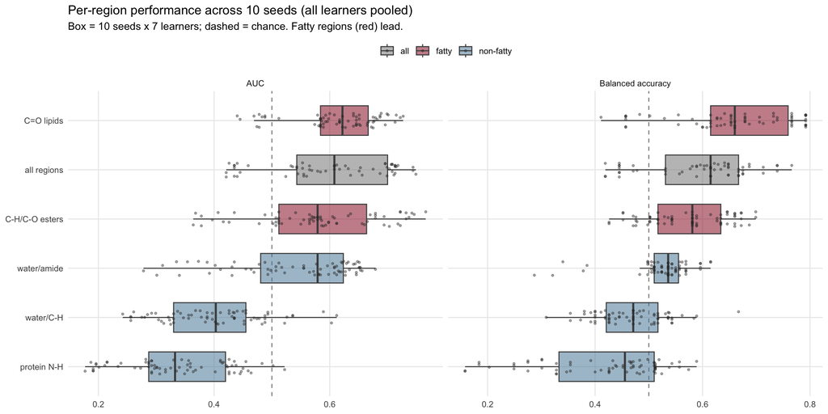

### 3.2 Per-learner Performance and Seed Stability

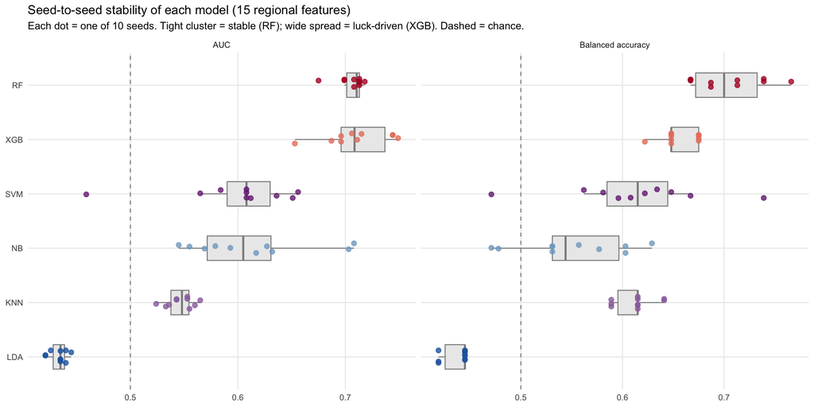

### 3.3 Hyperparameter Tuning on the Optimal Region

Table 4

| learner | mean_auc | sd_auc | mean_bacc | sd_bacc | mean_sens | sd_sens | mean_spec | sd_spec |
| --- | --- | --- | --- | --- | --- | --- | --- | --- |
| XGB | 0.764 | 0.099 | 0.774 | 0.013 | 0.636 | 0.000 | 0.911 | 0.025 |
| RF | 0.637 | 0.020 | 0.716 | 0.025 | 0.591 | 0.048 | 0.842 | 0.035 |
| NB | 0.617 | 0.033 | 0.609 | 0.040 | 0.691 | 0.047 | 0.526 | 0.055 |
| SVM | 0.616 | 0.089 | 0.639 | 0.081 | 0.509 | 0.152 | 0.768 | 0.088 |
| LDA | 0.605 | 0.015 | 0.661 | 0.018 | 0.727 | 0.000 | 0.595 | 0.036 |
| KNN | 0.595 | 0.027 | 0.653 | 0.050 | 0.591 | 0.064 | 0.716 | 0.075 |
| QDA | 0.476 | 0.021 | 0.467 | 0.032 | 0.554 | 0.051 | 0.379 | 0.022 |

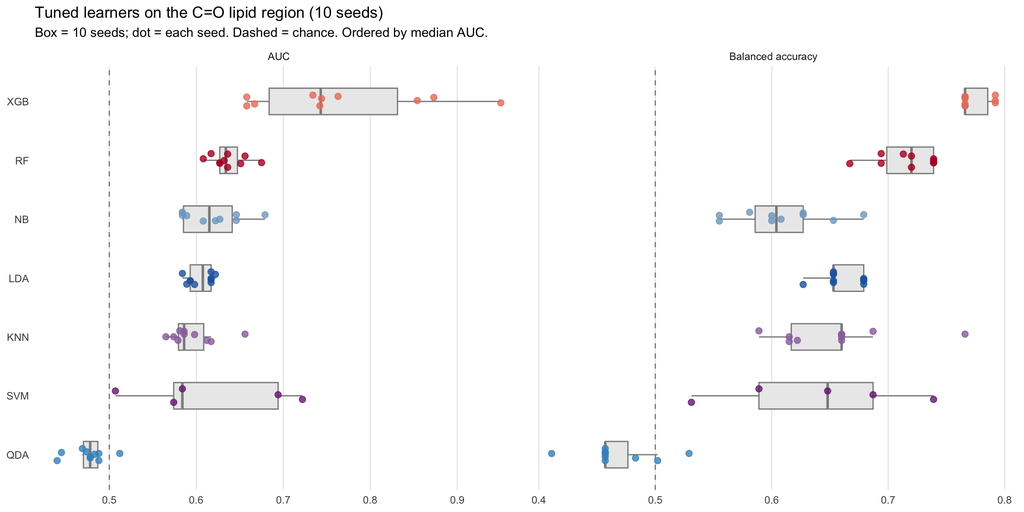

### 3.4 Sampling Uncertainty

The interpretation is sobering but important. While the point estimates indicate a moderate signal (AUC ≈ 0.65–0.67), localised in the lipid region and stable across seeds, the sampling intervals are wide and their lower bounds fall below chance (≈ 0.38–0.42). At n = 30, the data do not permit excluding, at conventional confidence levels, that the true performance is no better than chance. This does not contradict the earlier findings: the convergence of evidence across regions, models and seeds points consistently to a genuine, chemically coherent signal. It does, however, place a firm boundary on what can be claimed from this dataset. The results are best read as preliminary and hypothesis-generating: they identify where the freshness signal resides and what kind of model captures it, while demonstrating that a definitive estimate of its strength requires a substantially larger sample.

```
##    learner   auc delong_lo delong_hi boot_med boot_lo boot_hi boot_n
##     <char> <num>     <num>     <num>    <num>   <num>   <num>  <int>
## 1:      RF 0.646     0.383     0.909    0.616   0.390   0.872    725
## 2:     XGB 0.672     0.420     0.925    0.667   0.421   0.882    730
```

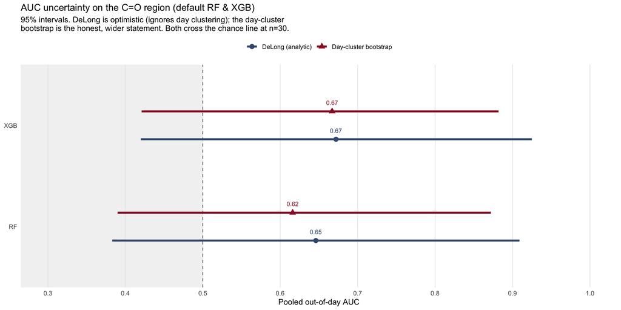